# Advanced Difference-in-Differences

EC 325: Econometrics

Prof. Caraher

Colby College

2026-11-19

## Econometrics So Far

- Started with the “gold standard” of causal inference: **RCTs**
- Then moved to **Multivariate OLS** and (even better) **fixed effects** with panel data
- Last time, started discussion on **DiD**: Using *control units* instead of *control variables*
- This time: more on DiD
  - Data-driven matching (IPW-DiD)
  - Dynamic DiD and event studies
  - Cluster-robust standard errors

# Data-Driven Matching

## Last Time: Choosing Controls by Intuition

- How do we know which control units to use? There is no one clear answer!
- It is common to start with some **intuition**: what “seems like” they should be a good fit?
- Card (1990) uses intuition: it “seems like” Atlanta, Tampa, LA, etc. would be a good fit for Miami
- **Border designs:** compare neighbors on opposite sides of a policy border
  - Neighbors share local economic conditions, so they are more likely to be on **parallel trends**
  - Card and Krueger (1994): fast-food restaurants in NJ vs. nearby eastern PA
  - Dube, Lester, and Reich (2010) extend this idea to *all* county pairs on state borders with different minimum wages (PS3 Q3 replicates a follow-up, Allegretto et al. 2017)

## Second Method: Data-Driven Selection of Controls

- An alternative: choose controls based on “data-driven” methods
- Use an algorithm to find “good” controls based on observable variables
- **The idea:** units that look alike on observable variables are more likely to share the same *trends*, so parallel trends is more believable among them
- There are *lots* of methods: synthetic controls, nearest-neighbors, propensity scores, etc.
- All share the same goal; they differ in the algorithm used
- We will focus on: **Inverse Propensity Score Weighted DiD (IPW-DiD)**

## IPW-DiD: The Example

- In 2014, many states expanded Medicaid eligibility under the ACA
- Suppose we want to estimate the **effect of Medicaid expansion on the uninsured rate**, using the same TWFE DiD as Unit 12:

$$y_{it} = \delta D_{it} + a_i + \tau_t + \mu_{it}$$

- $y_{it}$ is the uninsured rate in state $i$ in year $t$; $D_{it} = 1$ for expansion states from 2014 on

**The problem:** states which expanded Medicaid are *very different* from those that did not

- Different politics, different demographics, different incomes, etc.
- Using *all* non-expansion states as controls may give us a poor counterfactual
- In particular: if these characteristics also affect *trends* in uninsured rates, parallel trends will fail

## ACA Expansion Map

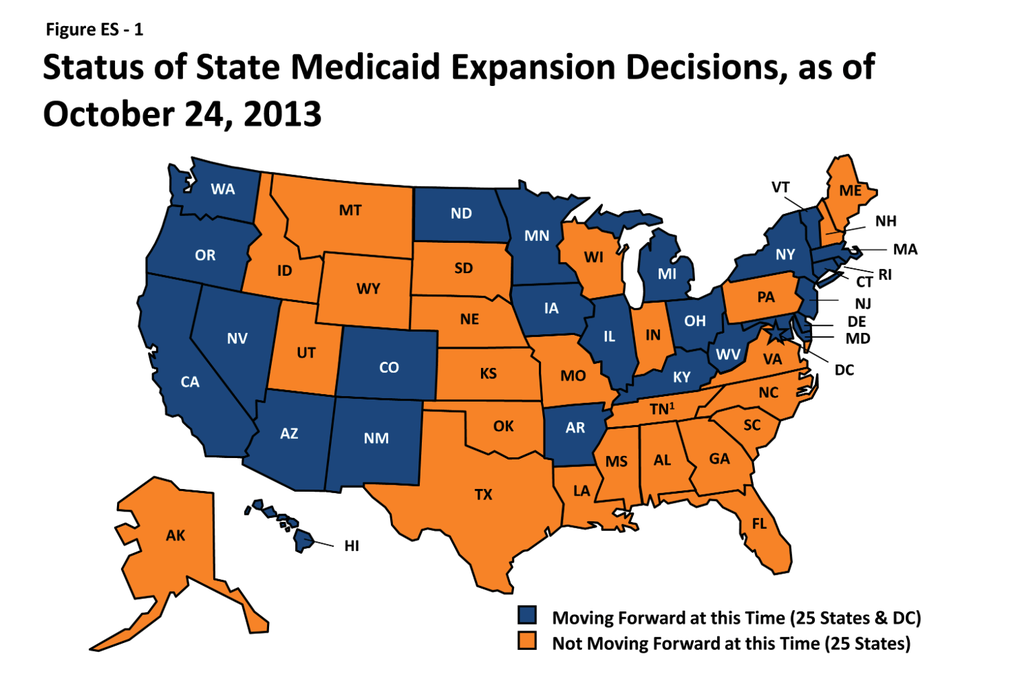

Map of ACA Expansion States

## ACA Expansion: Non-Parallel Pre-Trends

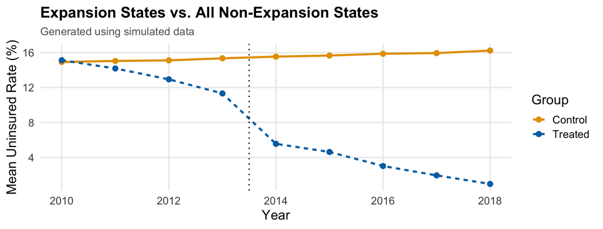

- States which expanded Medicaid follow very different trends compared to all non-expansion states
- Pre-trends are clearly not parallel — bad news for our DiD estimate!

## Choosing Better Control States

- We know that using *all* non-expansion states as controls is unwise
  - Violation of parallel trends $\rightarrow$ bad estimate
- So what can we do?
- Idea: use states which **look like they should have** expanded Medicaid **but didn’t** as controls
- Why?
  - States which were highly likely to expand but didn’t (maybe due to some last-minute change, a fluke in the political process, etc.) are much more *similar* to states which did expand
  - Therefore, they are more likely to form a “good” counterfactual

## Estimating Propensity Scores

- How do we find which states were “more likely” to expand?
- Estimate the following model:

$$P(D_{i} = 1 | x_1, ..., x_k) = G(\beta_0 + \beta_1 x_1 + ... + \beta_k x_k)$$

where:

- $D_{i}$ is an indicator equal to $1$ if a unit is in the treatment group (i.e., treated at any time)
- $P(D_{i} = 1 | x_1, ..., x_k)$ is the *probability of being in the treatment group conditional on $x$ variables*
- $G()$ is a non-linear function, usually the **logit** (Unit 10)
- After estimating this regression, compute the *predicted probability of treatment,* $\hat{P_i}$, also called the **propensity score**

## From Predicted Probabilities to Weights

- Then compute the **inverse propensity weight** and use it as a *weight* in TWFE DiD:

$$IPW_i = D_i + (1 - D_i)\frac{\hat{P_i}}{1 - \hat{P_i}}$$

- If a unit is **treated** ($D_i=1$): $IPW_i = 1$
- If a unit is **untreated** ($D_i=0$): $IPW_i = \frac{\hat{P_i}}{1 - \hat{P_i}}$, which is large when $\hat{P_i}$ is large and small when $\hat{P_i}$ is small
- In other words:
  - Untreated units that *look like* they should have been treated (but didn’t) get **a lot of weight** as a control
  - Untreated units that look *nothing like* treated units get **very little weight** as a control
- The weighted controls look like the **treated** group, so IPW-DiD still estimates the **ATT**

## Propensity Score Example

- Whether or not a state expands Medicaid is probably a function of (at least):
  - Democratic vote share, region, and poverty rates (Democrats and poorer states were more supportive; neighbors tend to follow neighbors)

$$P(D_i = 1) = G(\beta_0 + \beta_1 dem\_share_i + \beta_2 region_i + \beta_3 pov\_rate_i)$$

- Some illustrative propensity scores ($\hat{P_i}$) and IPW weights ($IPW_i$):

| State | Status | $\hat{P_i}$ | $IPW_i$ |
| --- | --- | --- | --- |
| MI | Treated | 0.91 | 1.00 |
| WI | Control | 0.87 | **6.69** |
| TX | Control | 0.16 | 0.19 |
| ME | Control | 0.79 | **3.76** |
| MA | Treated | 0.98 | 1.00 |
| GA | Control | 0.28 | 0.39 |

## What the Weights Do

- Without IPW, every control state counts equally in the construction of the counterfactual. With IPW, controls that *look like* treated states (**WI**, **ME**) count much more; controls that don’t (**TX**, **GA**) barely count

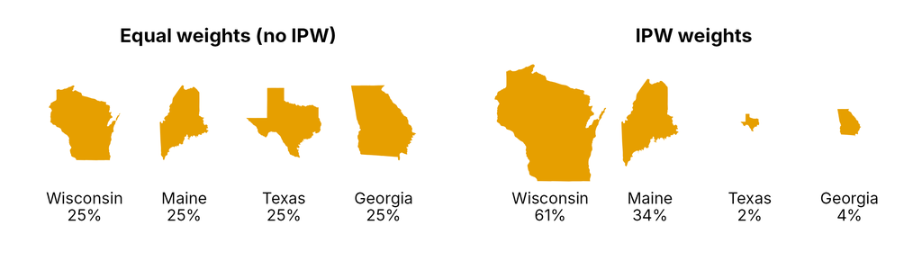

Each control state’s share of the control group (among these four)

**Key Point**

IPW upweights control units which *likely should have got treated but didn’t* and downweights *control units which were never going to be treated.* This builds a better counterfactual.

## Let’s Implement This Step-by-Step

- In our simulated data (200 simulated “states”), the **true effect** of expansion is a $-5$ point drop in the uninsured rate

**Step 1:** Estimate the naive TWFE DiD (all controls, equal weight)

```r
did_naive <- feols(uninsured_rate ~ treat_post | state_id + year,
                   vcov = "HC1",
                   data = aca_exp_data)

summary(did_naive)
```

```
OLS estimation, Dep. Var.: uninsured_rate
Observations: 1,800
Fixed-effects: state_id: 200,  year: 9
Standard-errors: Heteroskedasticity-robust
           Estimate Std. Error  t value  Pr(>|t|)
treat_post -10.9088   0.300973 -36.2451 < 2.2e-16 ***
---
Signif. codes:  0 '***' 0.001 '**' 0.01 '*' 0.05 '.' 0.1 ' ' 1
RMSE: 2.69942     Adj. R2: 0.814526
                Within R2: 0.460845
```

- The coefficient suggests a $\approx 11$ ppt reduction in the uninsured rate
- The estimate is roughly *twice as large* as it should be.

## Step 2: Aggregate Data & Estimate Propensity Scores

- It’s usually a good idea to estimate propensity scores on *just pre-treatment periods* (the policy itself can change later values of the $x$’s)

```r
agg_state_data <- aca_exp_data |>
  filter(post == 0) |>
  group_by(state_id, is_expanded) |>
  summarize(pretreat_dem_share = mean(dem_share, na.rm = TRUE),
    pretreat_region = mean(region, na.rm = TRUE),
    pretreat_pov_rate = mean(pov_rate, na.rm = TRUE)
  ) |>
  ungroup()

logit_treatment <- glm(
  is_expanded ~ pretreat_dem_share + pretreat_region + pretreat_pov_rate,
  data = agg_state_data, family = binomial("logit"))
```

## Step 3: Get Predicted Probabilities & Compute IPW

```r
# Get predicted probabilities (propensity scores)
agg_state_data <- agg_state_data |>
  mutate(pred_prob = predict(logit_treatment, type = "response"))

# Compute IPW weights
agg_state_data <- agg_state_data |>
  mutate(ipw = case_when(
    is_expanded == 1 ~ 1,
    is_expanded == 0 ~ pred_prob / (1 - pred_prob)
  ))

# Merge weights into panel data
aca_exp_data <- aca_exp_data |>
  left_join(agg_state_data |>
    select(state_id, is_expanded, pred_prob, ipw),
    by = c("state_id", "is_expanded"))
```

## Check Propensity Score Overlap

- We need treated and control propensity scores to **overlap**: wherever there are treated states, we need control states with similar $\hat{P_i}$

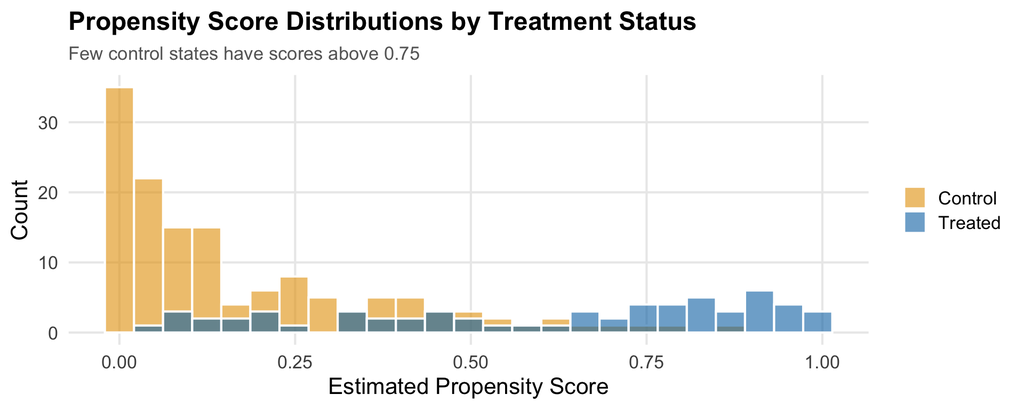

- Here, overlap is thin at the top: only 3 control states (vs. 26 treated) have $\hat{P_i} > 0.75$, so those few get very large weights

## Step 4: Estimate IPW-Weighted TWFE DiD

- Use the `weights` argument from `feols()` to weight the control units in the regression

```r
did_ipw <- feols(uninsured_rate ~ treat_post | state_id + year,
                 vcov = "HC1",
                 weights = ~ipw,
                 data = aca_exp_data)

summary(did_ipw)
```

```
OLS estimation, Dep. Var.: uninsured_rate
Observations: 1,800
Weights: ipw
Fixed-effects: state_id: 200,  year: 9
Standard-errors: Heteroskedasticity-robust
           Estimate Std. Error  t value  Pr(>|t|)
treat_post -6.24311   0.378796 -16.4815 < 2.2e-16 ***
---
Signif. codes:  0 '***' 0.001 '**' 0.01 '*' 0.05 '.' 0.1 ' ' 1
RMSE: 2.30334     Adj. R2: 0.844251
                Within R2: 0.3094
```

- Now we get an estimated treatment effect of $\approx -6$ ppts — much closer to the true effect of $-5$!

## Comparing Naive vs. IPW: The Trends

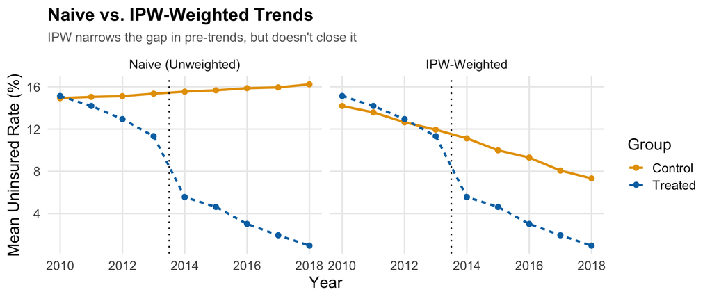

- Before 2014, the IPW-weighted controls are much closer to the treated states’ trend, but not parallel: that leftover gap is why we’re still about 1 point off

## Comparing Naive vs. IPW: The Estimates

| Method | Estimate | 95% CI Lower | 95% CI Upper | True Effect |
| --- | --- | --- | --- | --- |
| Naive DiD (all controls, equal weight) | -10.91 | -12.02 | -9.80 | -5.00 |
| IPW-Weighted DiD | -6.24 | -7.79 | -4.70 | -5.00 |

- The naive 95% CI doesn’t even contain the true effect of $-5$!
- The IPW estimate is much closer to the truth, and its CI covers $-5$

## Leave Out a Variable

- Our propensity score model used Democratic vote share, region, and poverty rate
- Suppose we **left one of them out** of the logit. Which omission would hurt the IPW-DiD estimate most? Why?

| Propensity score model | IPW-DiD estimate | True effect |
| --- | --- | --- |
| All three variables | -6.24 | -5 |
| Without Democratic vote share | -9.66 | -5 |
| Without poverty rate | -7.83 | -5 |
| Without region | -6.89 | -5 |

- Leaving out a variable that drives *both* expansion *and* trends in the uninsured rate brings the bias back

## IPW-DiD: Key Takeaways

- DiD assumes parallel trends. This often fails if treated and control units are systematically different
- IPW puts more weight on controls which were **highly likely to be treated but were not** — they are more similar to the treated units
- **The Algorithm:**
  1. Estimate predicted probability of treatment (propensity score) using pre-treatment data
  2. Compute IPW from predicted probabilities and treatment status
  3. Check that treated and control propensity scores overlap
  4. Use IPW as weights in TWFE DiD regression

**Important**

Your IPW-DiD estimate is only as good as your predictive model! If you leave out an important confounder, bias remains.

# Dynamic DiD

## Introduction to Dynamic DiD

- TWFE models can be extended to estimate a **separate** treatment effect for each period
  - If treatment starts in 2015 and we observe 2015–2018, we can estimate a different effect for each year
- Why might we want to do this?
  - Maybe the treatment effect **grows** a few years after a policy comes into effect
  - Or maybe it **diminishes** over time
- Dynamic DiD uses **relative time**: the number of periods since the event
  - If an event occurs in 2015: for **2015, 2016, 2017, …**, relative time is **0, 1, 2, …**
  - For **…, 2012, 2013, 2014**, relative time is **…, -3, -2, -1**

## The Dynamic DiD Model

- The general dynamic DiD model is:

$$y_{it} = \sum_{k \neq -1} \delta_k D^k_{it} + a_i + \tau_t + \mu_{it}$$

where:

- $y_{it}$, $a_i$, $\tau_t$, and $\mu_{it}$ are the same as in our TWFE model
- $D^k_{it}$ is a dummy that equals $1$ if unit $i$ is in the treated group AND period $t$ is relative time $k$, and $0$ otherwise
- **Important:** We **omit** the dummy for $k=-1$ (the period just before treatment) as the reference category
- For $k \geq 0$, $\hat{\delta}_k$ traces out the effect of the policy after adoption, *relative* to $k=-1$
- For $k \leq -2$, $\hat{\delta}_k$ traces out the “effect” *before* adoption, *relative* to $k=-1$

## Why Omit $k=-1$?

- Same reason we omit a reference category with any set of dummy variables — to avoid perfect collinearity (the “dummy variable trap”)
- We choose $k=-1$ because it’s the natural baseline:
  - All estimates are then interpreted as the treatment effect *relative to the period just before treatment*
  - $\hat{\delta}_0$: effect in the year of treatment relative to the year before
  - $\hat{\delta}_1$: effect one year after treatment relative to the year before
  - $\hat{\delta}_{-3}$: “effect” three years before treatment relative to the year before (should be $\approx 0$!)

## Example Data Structure

- In a normal DiD, we have a single `treat_post` column
- In dynamic DiD, we replace it with a **dummy for each relative time period** interacted with treatment
- Shown: one treated unit (1) and one control unit (3)

```
   unit_id year treatment_group rel_t_treat_-2 rel_t_treat_-1 rel_t_treat_0 rel_t_treat_1 rel_t_treat_2
1        1 2014               1              1              0             0             0             0
2        1 2015               1              0              1             0             0             0
3        1 2016               1              0              0             1             0             0
4        1 2017               1              0              0             0             1             0
5        1 2018               1              0              0             0             0             1
6        3 2014               0              0              0             0             0             0
7        3 2015               0              0              0             0             0             0
8        3 2016               0              0              0             0             0             0
9        3 2017               0              0              0             0             0             0
10       3 2018               0              0              0             0             0             0
```

## Dynamic DiD Example: An Environmental Policy

- Simulated: 50 cities, 1995–2010; 25 enact an *environmental policy* in 2005, 25 do not
- The policy’s effect on manufacturing employment *grows* over time

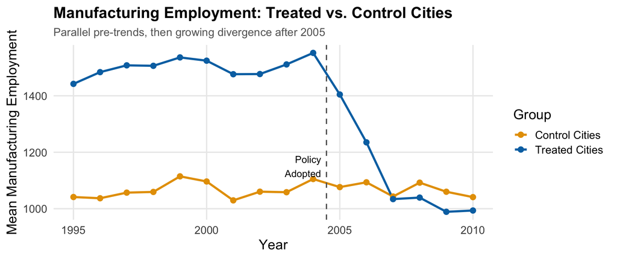

Note: figure generated using simulated data. True effects: $-100$ at $k=0$, growing to $-500$ by $k=3$.

## Estimating the Dynamic Model

```r
dyn_did <- feols(manufacturing_emp ~ `rel_t_treat_-10` + `rel_t_treat_-9` +
    `rel_t_treat_-8` + `rel_t_treat_-7` + `rel_t_treat_-6` +
    `rel_t_treat_-5` + `rel_t_treat_-4` + `rel_t_treat_-3` +
    `rel_t_treat_-2` + `rel_t_treat_0` + `rel_t_treat_1` +
    `rel_t_treat_2` + `rel_t_treat_3` + `rel_t_treat_4` +
    `rel_t_treat_5` |
    city_id + year,
    vcov = "HC1",
    data = final_simulated_data)
```

- Note: we leave `rel_t_treat_-1` (the period right before treatment) out of the formula: it’s the reference category
- Each coefficient = treatment effect at that relative time, compared to $k = -1$

## Interpreting the Results

```r
summary(dyn_did)
```

```
OLS estimation, Dep. Var.: manufacturing_emp
Observations: 800
Fixed-effects: city_id: 50,  year: 16
Standard-errors: Heteroskedasticity-robust
                     Estimate Std. Error    t value         Pr(>|t|)
`rel_t_treat_-10`  -45.891986    20.8395  -2.202162 0.02797020169001 *
`rel_t_treat_-9`     0.032430    21.8538   0.001484 0.99881639303762
`rel_t_treat_-8`     4.200795    21.3792   0.196490 0.84428235245665
`rel_t_treat_-7`     0.004546    23.3134   0.000195 0.99984445634205
`rel_t_treat_-6`   -25.407032    20.7310  -1.225557 0.22076633323870
`rel_t_treat_-5`   -18.816323    21.7368  -0.865646 0.38697291231614
`rel_t_treat_-4`     0.190090    20.0074   0.009501 0.99242205970984
`rel_t_treat_-3`   -30.032327    20.7426  -1.447857 0.14809243671973
`rel_t_treat_-2`     5.899519    20.8296   0.283228 0.77708353411990
rel_t_treat_0     -118.727649    19.1594  -6.196822 0.00000000096929 ***
rel_t_treat_1     -305.130219    21.6454 -14.096784        < 2.2e-16 ***
rel_t_treat_2     -455.941394    20.6898 -22.037036        < 2.2e-16 ***
rel_t_treat_3     -499.662713    21.8847 -22.831593        < 2.2e-16 ***
rel_t_treat_4     -517.799223    21.9008 -23.642990        < 2.2e-16 ***
rel_t_treat_5     -494.140275    21.8736 -22.590724        < 2.2e-16 ***
---
Signif. codes:  0 '***' 0.001 '**' 0.01 '*' 0.05 '.' 0.1 ' ' 1
RMSE: 47.7     Adj. R2: 0.962362
             Within R2: 0.825985
```

## Interpreting the Coefficients

Each $\hat{\delta}_k$ is the estimated treatment effect at relative time $k$, **relative to $k = -1$**

- $\hat{\delta}_{-3} \approx -30$: Three years before adoption, treated cities had 30 fewer manufacturing jobs than control cities *compared to one year before adoption*. Not statistically different from zero $\rightarrow$ no sign of a pre-trend.
- $\hat{\delta}_0 \approx -119$: In the adoption year, treated cities lost about 120 manufacturing jobs relative to control cities *compared to one year before adoption*. Statistically significant!
- $\hat{\delta}_3 \approx -500$: Three years after adoption, the gap had grown to about 500 fewer jobs. Statistically significant!

**Key points:**

- The coefficients are *not* the level of employment — they are *differences* between treated and control, benchmarked to the period just before the policy
- If $\hat{\delta}_{-5} = 0$ and $\hat{\delta}_{-2} = 0$ but $\hat{\delta}_0 = -100$, that’s the pattern parallel trends predicts: nothing happening pre-treatment, then a break at the policy date

## Pre-Treatment Results and Parallel Trends

- Why estimate effects *before* the policy occurs? To check for **pre-trends**: evidence for (not proof of) our key assumption, **parallel trends**
  - This is what Card (1990) couldn’t show with only one pre-period year
- $\hat{\delta}_{-3}$ is the treated–control gap at $k = -3$ relative to the gap at $k = -1$. If both groups were on the same trajectory, the gap wasn’t changing $\rightarrow$ $\hat{\delta}_{-3} \approx 0$
- If the pre-treatment $\hat{\delta}_k$’s are large and significant, the groups were drifting apart *before* the policy: any post-treatment divergence might just continue that trend
- Here, 8 of our 9 pre-treatment coefficients are close to zero. $\hat{\delta}_{-10}$ is significant at 5%, but with 9 tests, one false positive is not unusual: no *pattern* $\rightarrow$ **good evidence for parallel trends**

**Warning**

A *pattern* of significant pre-treatment coefficients (e.g., a steady drift): **red flag!** Your control group is probably not valid

## The Event-Study Plot

- Often, it is hard to read that many coefficients, so we plot them as an **event-study plot**
- We plot each coefficient (setting $k=-1$ to $0$) with its 95% confidence interval

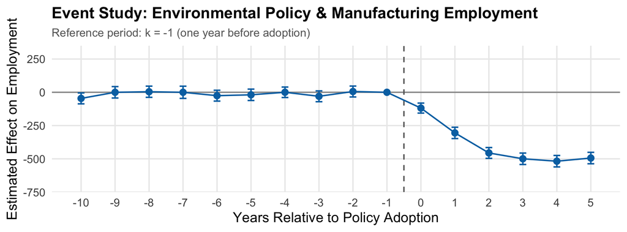

- **Left of the dashed line:** the pre-trends check. **Right of it:** the policy’s effect, growing over time

## A Warning: Staggered Adoption

- Our example was “simple”: all treated cities adopted the policy in the same year (2005)
- This is called **simultaneous adoption**
- What if units are treated in different years? (e.g., some cities in 2005, others in 2007, more in 2010)
- This is **staggered adoption**, and it’s common: the real Medicaid expansion was staggered (most states in 2014; PA and IN in 2015; LA in 2016; more since)

**Warning**

Under staggered adoption, simple TWFE (static or dynamic) can be very biased **when treatment effects change over time or differ across adoption groups**, like our environmental policy, whose effect grows. TWFE implicitly uses already-treated units as controls for later-treated units, creating “negative weights” on some treatment effects. Use methods built for staggered adoption: `sunab()` in `fixest` (Sun and Abraham) or the Callaway-Sant’Anna estimator in the `did` package.

## Dynamic DiD: Key Takeaways

1. Dynamic DiD estimates treatment effects that **evolve over time**
2. The model uses **relative time** ($k$), not calendar time
3. We **omit** $k=−1$ (period just before treatment) as the reference category
4. Pre-treatment coefficients ($k < -1$) check for **pre-trends**: evidence for parallel trends, not proof — they should be $\approx 0$, with no pattern
5. Present your results using an **event study plot**
6. The simple TWFE model can **fail under staggered adoption** when effects change over time

# Cluster-Robust Standard Errors

## The Core Problem: An Intuitive Example

- Imagine you want to know the average height of 5th graders in a city
- You have two sampling options:
- **Plan A (Simple Random Sample):** Randomly select 1,000 5th graders from across the whole city
- **Plan B (Cluster Sample):** Randomly select 40 classrooms and measure all 25 students in each
- Both plans give you $N = 1{,}000$ observations. But are they the same?
- **No!** In Plan B, students in the same class are more similar to each other (shared teacher, neighborhood, etc.). They are not *independent!*

## What is a “Cluster”?

- A **cluster** is a group of observations that are more similar to each other than to observations in other groups
- Errors from our regression are *correlated within the cluster*
- But errors from our regression are still *independent between clusters*

| Individual unit ($n$) | Cluster ($G$) |
| --- | --- |
| Student | Classroom |
| Person | State (or county) |
| City | State |
| Firm | Industry |
| State-year (panel data) | State |

- Why is this a problem for our standard errors?

## The Statistical Violation

- This violates **GM2 (random sampling)**: observations are no longer independent (heteroskedasticity broke GM5 in Unit 9)
- If one student in a class has a higher *error term*, her classmates probably do too $\rightarrow$ correlated errors within each cluster
- Just like **heteroskedasticity**, clustered errors will **not bias** your coefficient estimate $\hat{\beta}$
- But our usual standard errors are often far **too small**: t-statistics too big, p-values too small, confidence intervals too narrow
- This leads to **Type I errors (false positives)**: concluding there is an effect when, in reality, there is none
- We usually accept a 5% false positive rate ($\alpha = 0.05$). Ignoring clustering can push it far higher…
- …all while R tells us the p-value is 0.03!

## Why DiD Needs Clustered SEs

- DiD follows the *same states* over *many years*: a state’s errors are correlated from year to year, so each state is a cluster
- Bertrand, Duflo, and Mullainathan (2004) made up **fake (“placebo”) state laws**, assigned at random, and estimated their “effects” on women’s wages with DiD
- The laws were fake, so the true effect was zero. Yet with about 20 years of state-level data, the usual standard errors found a “significant” effect at 5% for **up to 45% of the fake laws**
- Their fix: allow errors to be correlated within each state (cluster by state)

## Simulation: Setup

- Let’s see how bad this problem gets with a simulation
- We generate data where the **true treatment effect is zero**, so *any* rejection of $H_0$ is a **Type I error**
- Treatment is assigned to **whole clusters** (like a state policy): every student in a classroom is treated, or none is

| Parameter | Value | Meaning |
| --- | --- | --- |
| Number of clusters ($G$) | 50 | e.g., 50 classrooms |
| Observations per cluster | 30 | e.g., 30 students per classroom |
| Total observations ($N$) | 1,500 | $50 \times 30$ |
| ICC | 0.5 | 50% of the variation in $y$ is between clusters |
| True treatment effect | **0** | Treatment does *nothing* |
| Number of simulations | 1,000 | We repeat the experiment 1,000 times |

- Each time: run `feols(y ~ treatment)`, get p-values with **naive (iid)** and **HC1** standard errors, and check whether we reject $H_0$ at $\alpha = 0.05$

## What Does Clustered Data Look Like?

- Here is one draw (8 classrooms, for clarity). Students in the same classroom share a common error component, and the whole classroom is either treated or not

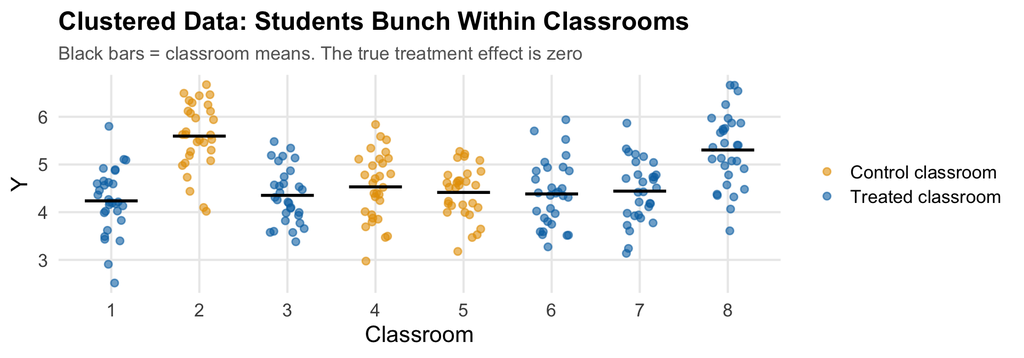

- OLS treats all 240 dots as independent, but each classroom is closer to *one* piece of information about treatment

## Results: Naive OLS and HC1

```
--- Type I Error Rate (Expected: 5%) ---
```

```
1. Naive (iid) Standard Errors:              63.6%
```

```
2. Heteroskedasticity-Robust (HC1) Errors:   63.5%
```

- Naive OLS: **massive** over-rejection. We are committing Type I errors far more than 5% of the time
- HC1 (our usual `vcov = "HC1"` fix): still way too many false positives!
  - HC1 corrects for *heteroskedasticity* but **not** for *within-cluster correlation*
- Neither of our usual standard error approaches works here. We need something new.

## The Solution: Cluster-Robust Standard Errors

- **Cluster-Robust Standard Errors (CRSEs)** allow correlated errors *within* clusters (but not *between* them). Recall Unit 9’s robust (HC1) formula:

$$se(\hat{\beta}_1)^2 = \frac{\sum_{i=1}^{n} (x_i - \bar{x})^2 \, (\hat{\mu}_i)^2}{SST_x^2}$$

- CRSEs **add up within each cluster $g$ first**, then square:

$$se(\hat{\beta}_1)^2 = \frac{\sum_{g=1}^{G} \left( \sum_{i \in g} (x_i - \bar{x}) \, \hat{\mu}_i \right)^2}{SST_x^2}$$

- If treatment is the same for everyone in a cluster, so is $(x_i - \bar{x})$: correlated errors pile up instead of canceling $\rightarrow$ a bigger SE
- **Rule of thumb:** the “effective sample size” is closer to $G$ than to $N$ (here, about 100, not 1,500)

## CRSEs in R

- With `fixest`, implementing CRSEs is easy
- Instead of `vcov = "HC1"`, use `cluster = "your_cluster_var"`

```r
# Naive standard errors (WRONG with clustered data)
model <- feols(y ~ treatment, data = my_data, vcov = "iid")

# Heteroskedasticity-robust (ALSO WRONG with clustered data)
model <- feols(y ~ treatment, data = my_data, vcov = "HC1")

# Cluster-robust standard errors (CORRECT)
model <- feols(y ~ treatment, data = my_data, cluster = "cluster_id")
```

- The researcher must decide what the clusters are: more on this shortly

## Now Let’s See If CRSEs Fix the Problem

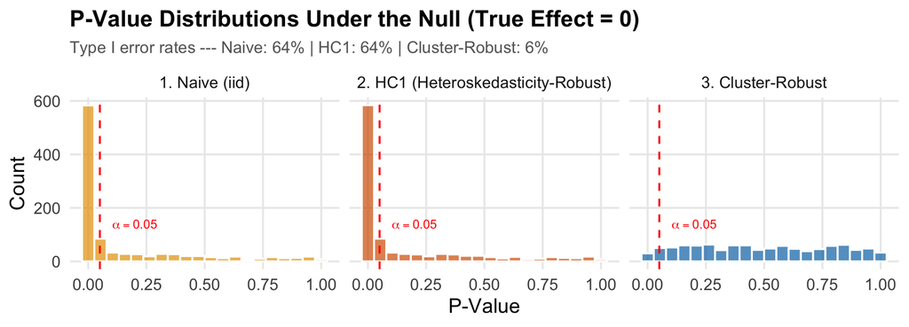

- Under $H_0$, p-values should be spread evenly (a flat histogram). Naive and HC1: they pile up near zero
- **Cluster-robust SEs: roughly flat, with a Type I error rate close to the target 5%!**
- Even with correct SEs, 5% of tests reject by chance: remember $\hat{\delta}_{-10}$ in our event study?

## Try It: Assign Treatment to Students

- Same simulation, one change: assign treatment to **individual students** instead of whole classrooms (the ICC is still 0.5)
- Predict: what happens to the naive (iid) Type I error rate? Do we still need to cluster?

```
--- Type I Error Rate, treatment assigned to students (Expected: 5%) ---
```

```
1. Naive (iid) Standard Errors:              4.9%
```

```
2. Cluster-Robust Standard Errors:           4.7%
```

- Correlated errors alone aren’t the problem. It’s correlated errors **plus** a treatment that is the same for everyone in the cluster
- That’s why we **cluster at the level of treatment assignment**

## CRSEs in the ACA Example

- Medicaid expansion is a **state-level** policy, so we cluster by state. Here is our IPW-DiD:

```r
did_ipw_crse <- feols(uninsured_rate ~ treat_post | state_id + year,
                      cluster = "state_id",
                      weights = ~ipw,
                      data = aca_exp_data)

summary(did_ipw_crse)
```

```
OLS estimation, Dep. Var.: uninsured_rate
Observations: 1,800
Weights: ipw
Fixed-effects: state_id: 200,  year: 9
Standard-errors: Clustered (state_id)
           Estimate Std. Error  t value            Pr(>|t|)
treat_post -6.24311   0.784859 -7.95443 0.00000000000013307 ***
---
Signif. codes:  0 '***' 0.001 '**' 0.01 '*' 0.05 '.' 0.1 ' ' 1
RMSE: 2.30334     Adj. R2: 0.844251
                Within R2: 0.3094
```

- The coefficient is unchanged ($-6.24$): clustering does not affect the point estimate
- The SE roughly doubles (HC1: 0.38), so the 95% CI widens to include the true $-5$. These are the CIs in our naive vs. IPW table

## Choosing the Right Cluster Level

- So, *like* heteroskedasticity-robust SEs, easy to correct for
- But *unlike* heteroskedasticity-robust SEs, we have to choose how we think the clusters are defined
  - City data: cluster at the city-level? State-level? County?
  - Individual data: hospital-level? County-level?
- **General rule: cluster at the level of treatment assignment**
  - State-level policy $\rightarrow$ cluster by state; school-level program $\rightarrow$ cluster by school
  - Panel data: each unit’s observations over time form a cluster
- You generally need at least 30–50 clusters for CRSEs to work well
  - With only 2 cities, as in Card (1990), clustering can’t work: that’s why we skipped those SEs in Unit 12
- When in doubt, cluster at a broader level (e.g., state rather than county) — this will usually result in more conservative SEs

## CRSEs: Key Takeaways

- **Clustering is everywhere:** Data often comes in groups (classrooms, states, individuals over time)
- **Ignoring it is dangerous:** It leads to a massive inflation of **Type I errors** (false positives)
- **Use cluster-robust standard errors:** They provide reliable inference by relaxing the independence assumption
- **Cluster at the level of treatment assignment** (e.g., state-level policy $\rightarrow$ cluster by state)
- You generally need at least 30–50 clusters for CRSEs to work well